# 17. automatic document classification and attempted gridsearch

https://colab.research.google.com/drive/1JW2I6cU_ypfRXfIfqMPQwMEA6LzGav-Y#scrollTo=Imf7a7091OSB

```python
import pandas as pd
import numpy as np
import scipy.stats as scs
import statsmodels.api as sm
import matplotlib.pyplot as plt

%matplotlib inline
%config InlineBackend.figure_format='retina'
```

```python
df = pd.read_csv('small_700_through_710_descr_clm_code.csv')
df.drop('Unnamed: 0',axis=1, inplace=True)
df = df[(df['code']==705)|(df['code']==706)|(df['code']==700)]
df['descr_clm'] = df.descr + df.clm
df.drop(['descr','clm'],axis=1, inplace=True)
df['code'] = df['code'].astype('category')
df.head()
```

|  | code | descr_clm |
| --- | --- | --- |
| 0 | 700 | This application claims priority under 35 U.S.... |
| 1 | 700 | BACKGROUND \n 1. Field of Invention \n ... |
| 2 | 700 | CROSS-REFERENCE TO RELATED APPLICATIONS \n ... |
| 3 | 700 | FIELD OF THE INVENTION \n The present inve... |
| 4 | 700 | RELATED APPLICATION \n This application cl... |

```python
df['code'].value_counts()
```

```
706    1000
705    1000
700    1000
Name: code, dtype: int64
```

```python
df['category_id'] = df['code'].factorize()[0]
```

```python
df['category_id'].value_counts()
```

```
1    1000
2    1000
0    1000
Name: category_id, dtype: int64
```

```python
category_id_df = df[['code', 'category_id']].drop_duplicates().sort_values('category_id')
category_to_id = dict(category_id_df.values)
id_to_category = dict(category_id_df[['category_id', 'code']].values)
```

```python
id_to_category
```

```
{0: 700, 1: 705, 2: 706}
```

# Data exploration

```python
df.sample(5, random_state=0)
```

|  | code | descr_clm | category_id |
| --- | --- | --- | --- |
| 2077 | 700 | CROSS-REFERENCE TO RELATED APPLICATION(S) \n ... | 0 |
| 3401 | 706 | BACKGROUND \n Many systems are instrumente... | 2 |
| 4393 | 706 | FIELD \n The subject matter disclosed here... | 2 |
| 10648 | 705 | This application is a continuation of U.S. pat... | 1 |
| 10687 | 705 | BACKGROUND \n 1. Technical Field \n Em... | 1 |

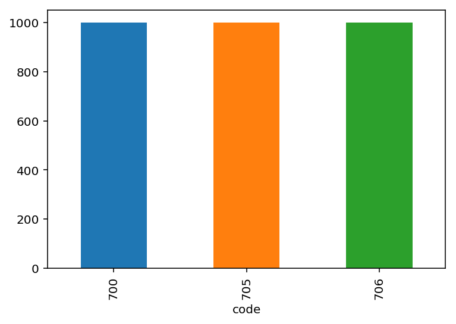

```python
df.groupby('code').descr_clm.count().plot.bar(ylim=0)
```

Here, we see that the number of articles per class is roughly balanced, which is helpful! If our dataset were imbalanced, we would need to carefully configure our model or artificially balance the dataset, for example by undersampling or oversampling each class.

To further analyze our dataset, we need to transform each article's text to a feature vector, a list of numerical values representing some of the text’s characteristics. This is because most ML models cannot process raw text, instead only dealing with numerical values.

One common approach for extracting features from text is to use the bag of words model: a model where for each document, an article in our case, the presence (and often the frequency) of words is taken into consideration, but the order in which they occur is ignored.

Specifically, for each term in our dataset, we will calculate a measure called Term Frequency, Inverse Document Frequency, abbreviated to tf-idf. This statistic represents words’ importance in each document. We use a word's frequency as a proxy for its importance: if "football" is mentioned 25 times in a document, it might be more important than if it was only mentioned once. We also use the document frequency (the number of documents containing a given word) as a measure of how common the word is. This minimizes the effect of stop-words such as pronouns, or domain-specific language that does not add much information (for example, a word such as "news" that might be present in most documents). We will use sklearn (also known as scikit-learn), a machine learning library that is particularly accessible to beginners. We use the TfidfVectorizer class to calculate a tf-idf vector for each of our documents:

sklearn.feature_extraction.text.TfidfVectorizer will be used to calculate a tf-idf vector for each of our documents. Note that we are passing a number of parameters to this class:

sublinear_df is set to True to use a logarithmic form for frequency, to give diminishing returns as the frequency of a word increases. This is usually preferable for a number of reasons, one of which being Zipf's Law. min_df is the minimum numbers of documents a word must be present in to be kept, and we are setting it to 5. This is to avoid rare words, which drastically increase the size of our features and might cause overfitting. norm is set to l2, to ensure all our feature vectors have a euclidian norm of 1. This is helpful for visualizing these vectors, and can also improve (or deteriorate) the performance of some models. encoding is set to latin-1 which is used by our input text. ngram_range is set to (1, 2) to indicate that we want to consider both unigrams and bigrams, or in other terms: we want to consider single words ("prices", "player") and pairs of words ("stock prices", "football player"). Finally, stop_words is set to "english" to remove all common pronouns ("a", "the", ...) and further reduce the number of noisy features.

```python
from sklearn.feature_extraction.text import TfidfVectorizer

tfidf = TfidfVectorizer(sublinear_tf=True, min_df=5, norm='l2', encoding='latin-1', ngram_range=(1, 2), stop_words='english')

features = tfidf.fit_transform(df['descr_clm']).toarray()
labels = df['category_id']
features.shape
```

```
(3000, 110325)
```

Each of our 3000 documents is now represented by 110325 features, representing the tf-idf score for different unigrams and bigrams.

This representation is not only useful for solving our classification task, but also to familiarize ourselves with the dataset. For example, we can use the chi-squared test to find the terms are the most correlated with each of the categories:

```python
from sklearn.feature_selection import chi2
```

```python
N = 3
for code, category_id in sorted(category_to_id.items()):
  features_chi2 = chi2(features, labels == category_id)
  indices = np.argsort(features_chi2[0])
  feature_names = np.array(tfidf.get_feature_names())[indices]
  unigrams = [v for v in feature_names if len(v.split(' ')) == 1]
  bigrams = [v for v in feature_names if len(v.split(' ')) == 2]
  print("# '{}':".format(code))
  print("  . Most correlated unigrams:\n       . {}".format('\n       . '.join(unigrams[-N:])))
  print("  . Most correlated bigrams:\n       . {}".format('\n       . '.join(bigrams[-N:])))
```

```
# '700':
  . Most correlated unigrams:
       . robot
       . control
       . controller
  . Most correlated bigrams:
       . control unit
       . perspective view
       . control device
# '705':
  . Most correlated unigrams:
       . merchant
       . transaction
       . payment
  . Most correlated bigrams:
       . service provider
       . credit card
       . point sale
# '706':
  . Most correlated unigrams:
       . neural
       . training
       . learning
  . Most correlated bigrams:
       . training data
       . machine learning
       . neural network
```

```python
N = 10
for code, category_id in sorted(category_to_id.items()):
  features_chi2 = chi2(features, labels == category_id)
  indices = np.argsort(features_chi2[0])
  feature_names = np.array(tfidf.get_feature_names())[indices]
  unigrams = [v for v in feature_names if len(v.split(' ')) == 1]
  bigrams = [v for v in feature_names if len(v.split(' ')) == 2]
  print("# '{}':".format(code))
  print("  . Most correlated unigrams:\n       . {}".format('\n       . '.join(unigrams[-N:])))
  print("  . Most correlated bigrams:\n       . {}".format('\n       . '.join(bigrams[-N:])))
```

```
# '700':
  . Most correlated unigrams:
       . temperature
       . direction
       . motor
       . position
       . sensor
       . controlling
       . power
       . robot
       . control
       . controller
  . Most correlated bigrams:
       . electric power
       . control signal
       . robot according
       . power supply
       . control method
       . method controlling
       . controller configured
       . control unit
       . perspective view
       . control device
# '705':
  . Most correlated unigrams:
       . card
       . price
       . sale
       . financial
       . transactions
       . credit
       . purchase
       . merchant
       . transaction
       . payment
  . Most correlated bigrams:
       . debit card
       . financial transaction
       . account number
       . payment transaction
```

[output cut: 14 more lines]

```
       . probability
       . neural
       . training
       . learning
  . Most correlated bigrams:
       . learning algorithm
       . model based
       . training set
       . artificial neural
       . knowledge base
       . artificial intelligence
       . neural networks
       . training data
       . machine learning
       . neural network
```

Although this first test proves the presence of terms specific to each category, there might still be too much noise in the data, making it impossible to clearly separate each category. One way to confirm that the feature space we are using is representative enough for our task (classifying articles into separate labels) to be solvable is to use dimensionality-reduction techniques: These methods project a high-dimensional vector into a lower number of dimensions, with different guarantees on this projection according to the method used:

Principal Component Analysis (PCA) and Truncated Singular Value Decomposition (Truncated SVD) are two popular method given their scalability to a large number of dimensions, but they perform poorly on some classes of problems (when the correlations between the data are non-linear). Kernel PCA, self-organizing maps and auto-encoders are often used when the correlations between the features' dimensions are non-linear. Given our dataset contains natural language, we are most likely in the second case and will use t-SNE, a popular dimensionality reduction technique used in many fields, including NLP.

```python
from sklearn.manifold import TSNE
```

[figure not shown]

```python
# Sampling a subset of our dataset because t-SNE is computationally expensive
SAMPLE_SIZE = int(len(features) * 0.3)
np.random.seed(0)
indices = np.random.choice(range(len(features)), size=SAMPLE_SIZE, replace=False)
projected_features = TSNE(n_components=2, random_state=0).fit_transform(features[indices])
colors = ['midnightblue', 'orange', 'darkgrey']
for category, category_id in sorted(category_to_id.items()):
    points = projected_features[(labels[indices] == category_id).values]
    plt.scatter(points[:, 0], points[:, 1], s=30, c=colors[category_id], label=category)
plt.title("tf-idf feature vector for each article, projected on 2 dimensions.",
          fontdict=dict(fontsize=15))
plt.legend()
```

# Model training and evaluation

```python
from sklearn.linear_model import LogisticRegression
from sklearn.ensemble import RandomForestClassifier
from sklearn.naive_bayes import MultinomialNB
from sklearn.model_selection import cross_val_score
```

```python
models = [
    RandomForestClassifier(n_estimators=200, max_depth=3, random_state=0),
    MultinomialNB(),
    LogisticRegression(random_state=0),
]
CV = 5
cv_df = pd.DataFrame(index=range(CV * len(models)))
entries = []
for model in models:
  model_name = model.__class__.__name__
  accuracies = cross_val_score(model, features, labels, scoring='accuracy', cv=CV)
  for fold_idx, accuracy in enumerate(accuracies):
    entries.append((model_name, fold_idx, accuracy))
cv_df = pd.DataFrame(entries, columns=['model_name', 'fold_idx', 'accuracy'])
```

```python
import seaborn as sns
```

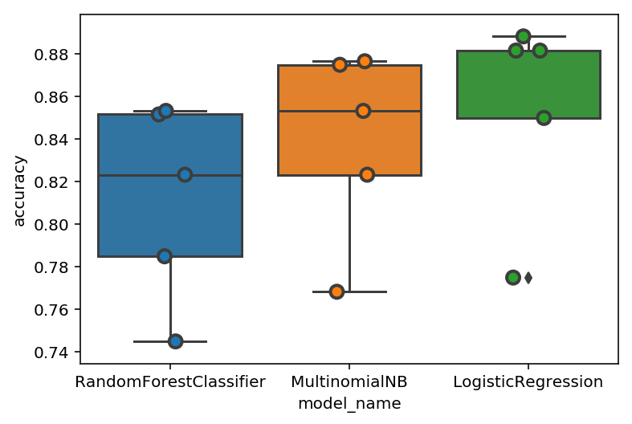

```python
sns.boxplot(x='model_name', y='accuracy', data=cv_df)
sns.stripplot(x='model_name', y='accuracy', data=cv_df,
              size=8, jitter=True, edgecolor="gray", linewidth=2);
```

```python
cv_df.groupby('model_name').accuracy.mean()
```

```
model_name
LogisticRegression        0.855333
MultinomialNB             0.839333
RandomForestClassifier    0.811667
Name: accuracy, dtype: float64
```

# Model interpretation

```python
from sklearn.model_selection import train_test_split
```

```python
model = LogisticRegression(random_state=0)

X_train, X_test, y_train, y_test, indices_train, indices_test = train_test_split(features, labels, df.index, test_size=0.33, random_state=0, stratify=df['code'])

model.fit(X_train, y_train)
y_pred_proba = model.predict_proba(X_test)
y_pred = model.predict(X_test)
```

```python
y_train.value_counts()
```

```
2    670
1    670
0    670
Name: category_id, dtype: int64
```

```python
y_test.value_counts()
```

```
2    330
1    330
0    330
Name: category_id, dtype: int64
```

```python
from sklearn.metrics import confusion_matrix
```

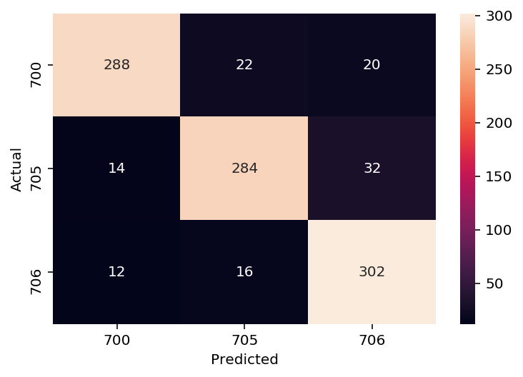

```python
conf_mat = confusion_matrix(y_test, y_pred)
sns.heatmap(conf_mat, annot=True, fmt='d',
            xticklabels=category_id_df.code.values, yticklabels=category_id_df.code.values)
plt.ylabel('Actual')
plt.xlabel('Predicted');
```

```python
from IPython.display import display

for predicted in category_id_df.category_id:
  for actual in category_id_df.category_id:
    if predicted != actual and conf_mat[actual, predicted] >= 2:
      print("'{}' predicted as '{}' : {} examples.".format(id_to_category[actual], id_to_category[predicted], conf_mat[actual, predicted]))
      display(df.loc[indices_test[(y_test == actual) & (y_pred == predicted)]][['descr_clm']])
      print('')
```

```
'705' predicted as '700' : 14 examples.
```

|  | descr_clm |
| --- | --- |
| 1902 | CROSS-REFERENCE TO RELATED APPLICATIONS \n ... |
| 10656 | TECHNICAL FIELD \n The present invention r... |
| 558 | CROSS-REFERENCES TO RELATED APPLICATIONS \n ... |
| 532 | CROSS-REFERENCE TO RELATED PATENT APPLICATION ... |
| 1896 | CROSS REFERENCE TO RELATED APPLICATIONS \n ... |
| 2345 | FIELD OF THE INVENTION \n Embodiments gene... |
| 2378 | BACKGROUND OF THE INVENTION \n 1. Field of... |
| 7992 | CROSS-REFERENCE TO RELATED APPLICATIONS \n ... |
| 4298 | CROSS-REFERENCE TO RELATED APPLICATIONS \n ... |
| 1872 | This application claims priority to U.S. Provi... |
| 8021 | RELATED PATENT APPLICATIONS \n This applic... |
| 4229 | RELATED APPLICATIONS \n The present invent... |
| 8083 | BACKGROUND \n Entities such as data center... |
| 8106 | CROSS-REFERENCE TO RELATED APPLICATIONS \n ... |

```
'706' predicted as '700' : 12 examples.
```

|  | descr_clm |
| --- | --- |
| 4704 | CROSS-REFERENCE TO RELATED APPLICATIONS \n ... |
| 2572 | CROSS-REFERENCE TO RELATED APPLICATIONS \n ... |
| 3105 | BACKGROUND \n Earth formations may be used... |
| 4630 | CROSS-REFERENCES TO RELATED APPLICATIONS \n ... |
| 3356 | RELATED APPLICATION INFORMATION \n This ap... |
| 3360 | BACKGROUND OF INVENTION \n 1. Field of the... |
| 4373 | RELATED APPLICATION INFORMATION \n The pre... |
| 3345 | CLAIM FOR PRIORITY \n This application cla... |
| 4481 | RELATED APPLICATIONS \n This application c... |
| 4607 | CROSS REFERENCE TO RELATED APPLICATIONS \n ... |
| 3303 | FIELD AND BACKGROUND OF THE INVENTION \n T... |
| 3351 | TECHNICAL FIELD \n The present invention r... |

```
'700' predicted as '705' : 22 examples.
```

|  | descr_clm |
| --- | --- |
| 3972 | This application claims the benefit of U.S. pr... |
| 743 | CROSS REFERENCE TO RELATED APPLICATIONS \n ... |
| 3707 | CROSS REFERENCE TO RELATED APPLICATIONS \n ... |
| 3850 | This application claims the benefit of U.S. Pr... |
| 757 | CROSS-REFERENCE TO RELATED APPLICATIONS \n ... |
| 3706 | BACKGROUND \n Shipments of items are often... |
| 3694 | CROSS REFERENCE TO RELATED APPLICATIONS \n ... |
| 6112 | CROSS-REFERENCE TO RELATED APPLICATIONS \n ... |
| 3748 | CLAIM OF BENEFIT TO PRIOR APPLICATION \n T... |
| 3761 | CROSS REFERENCE TO RELATED APPLICATIONS \n ... |
| 3700 | BACKGROUND \n Retailers, wholesalers, and ... |
| 3971 | TECHNICAL FIELD \n This disclosure relates... |
| 760 | CROSS-REFERENCE TO RELATED APPLICATION \n ... |
| 5149 | PRIORITY CLAIM \n This application is a co... |
| 788 | BACKGROUND \n Three-dimensional (3D) print... |
| 5186 | CROSS-REFERENCE TO RELATED APPLICATIONS \n ... |
| 5129 | BACKGROUND \n Shipments of items are often... |
| 2074 | This utility patent application is a continuat... |
| 2084 | PRIORITY APPLICATION \n This application i... |
| 5191 | The current application claims a priority to t... |
| 3746 | CROSS-REFERENCE TO RELATED APPLICATIONS \n ... |
| 3710 | CROSS REFERENCE TO RELATED APPLICATION \n ... |

```
'706' predicted as '705' : 16 examples.
```

|  | descr_clm |
| --- | --- |
| 3181 | RELATED APPLICATIONS \n This application i... |
| 3404 | CLAIM OF PRIORITY \n This application clai... |
| 3354 | CROSS-REFERENCE TO RELATED APPLICATIONS \n ... |
| 3176 | BACKGROUND \n 1. Field \n The system a... |
| 4693 | CROSS-REFERENCE TO RELATED APPLICATIONS \n ... |
| 3099 | CROSS-REFERENCE TO RELATED APPLICATIONS \n ... |
| 4430 | FIELD OF THE DISCLOSURE \n The present dis... |
| 3298 | CROSS-REFERENCE TO RELATED APPLICATIONS \n ... |
| 3304 | CROSS-REFERENCE TO RELATED APPLICATIONS \n ... |
| 3287 | CONTINUATION-IN-PART \n This application i... |
| 3174 | CROSS-REFERENCE TO RELATED APPLICATIONS \n ... |
| 4656 | TECHNICAL FIELD \n The present disclosure ... |
| 2554 | RELATED APPLICATIONS \n This application i... |
| 594 | CROSS REFERENCE TO OTHER APPLICATIONS \n T... |
| 4396 | CROSS REFERENCE TO RELATED APPLICATION \n ... |
| 4491 | CROSS-REFERENCE TO RELATED APPLICATIONS \n ... |

```
'700' predicted as '706' : 20 examples.
```

|  | descr_clm |
| --- | --- |
| 5227 | RELATED APPLICATIONS \n This application c... |
| 784 | TECHNICAL FIELD \n The present disclosure ... |
| 2076 | CLAIM OF PRIORITY \n This application is a... |
| 2092 | CROSS REFERENCE TO RELATED APPLICATIONS \n ... |
| 2117 | CROSS-REFERENCE TO RELATED APPLICATIONS \n ... |
| 2090 | CROSS-REFERENCE TO RELATED APPLICATIONS \n ... |
| 2107 | CROSS REFERENCE TO RELATED APPLICATION \n ... |
| 5312 | FIELD OF THE INVENTION \n This description... |
| 5318 | RELATED APPLICATIONS \n This application c... |
| 2036 | FIELD \n Embodiments taught herein relate ... |
| 3641 | FIELD OF THE INVENTION \n The present inve... |
| 5061 | FIELD OF THE INVENTION \n The present inve... |
| 5082 | CROSS-REFERENCE TO RELATED APPLICATIONS \n ... |
| 5072 | CROSS-REFERENCE TO RELATED APPLICATIONS \n ... |
| 2085 | TECHNICAL FIELD \n This disclosure relates... |
| 5300 | REFERENCE TO RELATED APPLICATION \n This a... |
| 3961 | TECHNICAL FIELD \n The present disclosure ... |
| 774 | RELATED APPLICATIONS \n This application c... |
| 5341 | CROSS-REFERENCE TO RELATED APPLICATIONS \n ... |
| 5083 | TECHNICAL FIELD \n Embodiments of the subj... |

```
'705' predicted as '706' : 32 examples.
```

|  | descr_clm |
| --- | --- |
| 7101 | CROSS-REFERENCE TO RELATED APPLICATIONS \n ... |
| 10682 | BACKGROUND \n Advertisers increasingly see... |
| 7030 | This application is a continuation of U.S. Ser... |
| 7113 | BACKGROUND \n Product lifecycle management... |
| 7095 | FIELD OF THE INVENTION \n The present inve... |
| 8074 | RELATED APPLICATIONS \n This application i... |
| 8069 | TECHNICAL FIELD \n The present disclosure ... |
| 7029 | TECHNICAL FIELD \n Embodiments of the pres... |
| 7039 | CLAIM OF PRIORITY \n This application is a... |
| 530 | This application claims the benefit of U.S. Pr... |
| 8042 | REFERENCE TO RELATED APPLICATIONS \n This ... |
| 9311 | RELATED APPLICATIONS \n This patent applic... |
| 542 | CROSS-REFERENCE TO RELATED APPLICATIONS \n ... |
| 1903 | TECHNICAL FIELD OF THE INVENTION \n The in... |
| 572 | CROSS-REFERENCE TO RELATED APPLICATIONS \n ... |
| 7034 | RELATED APPLICATIONS \n This application c... |
| 10632 | TECHNICAL FIELD \n The present technology ... |
| 10643 | PRIORITY \n This application claims priori... |
| 9356 | TECHNICAL FIELD \n The present disclosure ... |
| 9327 | CROSS REFERENCE TO OTHER APPLICATIONS \n T... |
| 8046 | PRIORITY DATA \n This application claims p... |
| 9344 | CROSS-REFERENCE TO RELATED APPLICATIONS \n ... |
| 7105 | BACKGROUND \n This disclosure relates gene... |
| 7112 | BACKGROUND \n Online social networks allow... |
| 562 | BACKGROUND \n Unless otherwise indicated h... |
| 7119 | CROSS REFERENCE TO RELATED APPLICATIONS \n ... |
| 4255 | This application is a Continuation of U.S. app... |
| 7972 | FIELD OF THE INVENTION \n The present inve... |
| 9335 | This application relates to U.S. provisional p... |
| 566 | TECHNICAL FIELD \n The present invention r... |
| 9349 | CROSS REFERENCE TO RELATED APPLICATION \n ... |
| 8044 | CROSS-REFERENCE TO RELATED APPLICATIONS \n ... |

```python
model.fit(features, labels)
```

```
LogisticRegression(C=1.0, class_weight=None, dual=False, fit_intercept=True,
          intercept_scaling=1, max_iter=100, multi_class='ovr', n_jobs=1,
          penalty='l2', random_state=0, solver='liblinear', tol=0.0001,
          verbose=0, warm_start=False)
```

```python
from sklearn.feature_selection import chi2

N = 10
for category, category_id in sorted(category_to_id.items()):
  indices = np.argsort(model.coef_[category_id])
  feature_names = np.array(tfidf.get_feature_names())[indices]
  unigrams = [v for v in reversed(feature_names) if len(v.split(' ')) == 1][:N]
  bigrams = [v for v in reversed(feature_names) if len(v.split(' ')) == 2][:N]
  print("# '{}':".format(category))
  print("  . Top unigrams:\n       . {}".format('\n       . '.join(unigrams)))
  print("  . Top bigrams:\n       . {}".format('\n       . '.join(bigrams)))
```

```
# '700':
  . Top unigrams:
       . control
       . controller
       . power
       . controlling
       . robot
       . sensor
       . position
       . energy
       . temperature
       . operation
  . Top bigrams:
       . control device
       . controller configured
       . perspective view
       . method controlling
       . control unit
       . control method
       . electric power
       . power supply
       . control signal
       . control systems
# '705':
  . Top unigrams:
       . payment
       . transaction
       . price
       . customer
       . financial
       . purchase
       . transactions
       . provider
       . service
       . account
  . Top bigrams:
       . service provider
       . mobile device
       . point sale
       . method providing
```

[output cut: 14 more lines]

```
       . neural
       . predicting
       . knowledge
       . artificial
  . Top bigrams:
       . neural network
       . machine learning
       . training data
       . knowledge base
       . artificial intelligence
       . input data
       . readable storage
       . neural networks
       . artificial neural
       . data set
```

```python
df[df.descr_clm.str.lower().str.contains('machine learning')].code.value_counts()
```

```
706    178
705     17
700      8
Name: code, dtype: int64
```

**need to remove ',' ';' '\n' '\r'**

```python
texts = ["1. A system comprising:a memory that stores computer executable components a processor that executes computer executable components stored in the memory wherein the computer executable components comprise:a snapshot component that generates a first sequence of multi-dimensional time series data and a second sequence of multi-dimensional time series data from multi-dimensional time series data associated with at least two different data types generated by a data system over a consecutive period of time and a machine learning component that analyzes the first sequence of multi-dimensional time series data and the second sequence of multi-dimensional time series data using a convolutional neuralnetwork system to predict an event associated with the multi-dimensional time series data. 2. The system of claim 1 wherein the snapshot component generates a data matrix associated with the first sequence of multi-dimensional time series data and the second sequence of multi-dimensional time series data and wherein the machine learning component analyzes the data matrix using the convolutional neural network system. 3. The system of claim 1 wherein the machine learning component analyzes the first sequence of multi-dimensional time series data and the second sequence of multi-dimensional time series data using a parallel network of processing units associated with the convolutional neural network system and wherein performance of the processor to predict the event associated with the multi-dimensional time series data is improved by employing the convolutional neural network system. 4. The system of claim 1 wherein the snapshot component determines a size of the first sequence of multi-dimensional time series data and the second sequence of multi-dimensional time series data based on data associated with the convolutional neural network system. 5. The system of claim 1 wherein the snapshot component determines a set of parameters for the convolutional neuralnetwork system based on a classification of data associated with the convolutional neural network system. 6. The system of claim 1 wherein a portion of data from the first sequence of multi-dimensional time series data corresponds to the second sequence of multi-dimensional time series data and wherein the machine learning component analyzes the portion of the data. 7. The system of claim 1 wherein at least the first sequence of multi-dimensional time series data comprises dynamic data that is related to other data included in the first sequence of multi-dimensional time series data or the second sequence of multi-dimensional time series data and wherein the machine learning component analyzes the dynamic data. 8. The system of claim 1 wherein the snapshot component generates the first sequence of multi-dimensional time series data and the second sequence of multi-dimensional time series data based on feedback data indicative of information for tuning the first sequence of multi-dimensional time series data and the second sequence of multi-dimensional time series data. 9. The system of claim 1 wherein the machine learning component adjusts the convolutional neural network system based on feedback data indicative of information for tuning the convolutional neural network system. 10. The system of claim 1 wherein the convolutional neuralnetwork system is associated with nonlinear processing of features associated with the first sequence of multi-dimensional time series data and the second sequence of multi-dimensional time series data. 11. The system of claim 1 further comprising:a display component that generates a user interface to display output data associated with the event in a human interpretable format. 12-19. (canceled) 20. A computer program product for machine learning the computer program product comprising a computer readable storage medium having program instructions embodied therewith the program instructions executable by processor to cause the processor to:generate by the processor a data matrix based on first time series data associated with a first data source and second time series data associated with a second data source analyze by the processor the data matrix associated with the first time series data and the second time series data using a convolutional neural network system and generate by the processor prediction data that comprises a predicted event associated with the first time series data and the second time series data based on data generated by the convolutional neural network system. 21. The computer program product of claim 20 wherein the program instructions are further executable by the processor to cause the processor to:modify by the processor the data matrix based on the data generated by the convolutional neural network system. 22. The computer program product of claim 20 wherein the program instructions are further executable by the processor to cause the processor to:modify by the processor a convolutional neural networkassociated with the convolutional neural network system based on the data generated by the convolutional neuralnetwork system. 23. A computer program product for machine learning the computer program product comprising a computer readable storage medium having program instructions embodied therewith the program instructions executable by processor to cause the processor to:generate by the processor a data matrix based on multi-dimensional time series data associated with at least two different data types perform by the processor a convolutional neural network process based on the data matrix associated with the multi-dimensional time series data and generate by the processor prediction data that comprises a predicted event associated with the multi-dimensional time series data based on the convolutional neural network process. 24. The computer program product of claim 23 wherein the program instructions are further executable by the processor to cause the processor to:modify by the processor the data matrix based on the prediction data. 25. The computer program product of claim 23 wherein the program instructions are further executable by the processor to cause the processor to:modify by the processor a convolutional neural networkassociated with the convolutional neural network process based on the prediction data."]
text_features = tfidf.transform(texts)
predictions = model.predict(text_features)
for text, predicted in zip(texts, predictions):
  print('"{}"'.format(text))
  print("  - Predicted as: '{}'".format(id_to_category[predicted]))
  print("")
```

```
"1. A system comprising:a memory that stores computer executable components a processor that executes computer executable components stored in the memory wherein the computer executable components comprise:a snapshot component that generates a first sequence of multi-dimensional time series data and…
  - Predicted as: '706'
```

https://patentimages.storage.googleapis.com/e2/3f/75/2f32412145e159/US20180260697A1.pdf